# notebook_main

## **Setup the Project Path**

```python
import sys
from pathlib import Path

# Add project root (parent of notebooks/) to Python path so "import src" works
PROJECT_ROOT = Path.cwd().parent  # .../EC334_Summative
if str(PROJECT_ROOT) not in sys.path:
    sys.path.insert(0, str(PROJECT_ROOT))
```

```python
# Performing necessary imports
import numpy as np
import pandas as pd
import matplotlib.pyplot as plt

import statsmodels.api as sm

from src.dataset import build_dataset  # this should already work in your repo

# Checking train and test data
data = build_dataset()
df_full  = data["full"].copy()
df_train = data["train"].copy()
df_test  = data["test"].copy()

print("Shapes:", df_full.shape, df_train.shape, df_test.shape)
print("Train period:", df_train["period_q"].min(), "to", df_train["period_q"].max())
print("Test period :", df_test["period_q"].min(), "to", df_test["period_q"].max())
```

```
Shapes: (224, 67) (208, 67) (16, 67)
Train period: 1968Q1 to 2019Q4
Test period : 2020Q1 to 2023Q4
```

### **Quick Sanity Check**

```python
y_var = "pi_pce_yoy"
x_vars = ["exp_mich_1y_mean", "u_gap_nroust"]

need_cols = ["period_q", "date", y_var] + x_vars
missing = [c for c in need_cols if c not in df_full.columns]
print("Missing columns:", missing)

# Missingness summary (train/test)
for c in [y_var] + x_vars:
    print(f"{c:>20} | train NA={df_train[c].isna().sum():>4} | test NA={df_test[c].isna().sum():>2}")
```

```
Missing columns: []
          pi_pce_yoy | train NA=   4 | test NA= 0
    exp_mich_1y_mean | train NA=   0 | test NA= 1
        u_gap_nroust | train NA=   0 | test NA= 1
```

#### **Checking which test quarter is missing**

```python
y_var = "pi_pce_yoy"
x_vars = ["exp_mich_1y_mean", "u_gap_nroust"]

dtest = df_test[[y_var] + x_vars + ["period_q", "date"]].copy()

missing_rows = dtest[dtest[x_vars].isna().any(axis=1)]
print("Missing RHS rows in test:")
print(missing_rows[["period_q", "date"] + x_vars])
```

```
Missing RHS rows in test:
    period_q                          date  exp_mich_1y_mean  u_gap_nroust
223   2023Q4 2023-12-31 23:59:59.999999999               NaN           NaN
```

```python
# Checking whether missingness is only for mean/median vars
for var in ["exp_mich_1y_mean", "exp_mich_1y_median"]:
    print(var, "test NA:", df_test[var].isna().sum())

df_test.loc[df_test["u_gap_nroust"].isna(), ["period_q", "UNRATE", "NROUST", "u_gap_nroust", "u_gap_nrou"]]
```

```
exp_mich_1y_mean test NA: 1
exp_mich_1y_median test NA: 0
```

|  | period_q | UNRATE | NROUST | u_gap_nroust | u_gap_nrou |
| --- | --- | --- | --- | --- | --- |
| 223 | 2023Q4 | NaN | 4.418317 | NaN | NaN |

## **Analysis Section 1: Baseline + Expectations Horse Race (OOS 2020Q1 - 2023Q3)**

```python
TEST_END = pd.Period("2023Q3", freq="Q")

df_test_common = df_test[df_test["period_q"] <= TEST_END].copy()

print("Original test window:", df_test["period_q"].min(), "to", df_test["period_q"].max(), "| N =", len(df_test))
print("Common test window  :", df_test_common["period_q"].min(), "to", df_test_common["period_q"].max(), "| N =", len(df_test_common))

# Quick check: confirm we're not carrying missing unemployment into the evaluation set
print("Missing UNRATE in original test:", df_test["UNRATE"].isna().sum())
print("Missing UNRATE in common test  :", df_test_common["UNRATE"].isna().sum())
```

```
Original test window: 2020Q1 to 2023Q4 | N = 16
Common test window  : 2020Q1 to 2023Q3 | N = 15
Missing UNRATE in original test: 1
Missing UNRATE in common test  : 0
```

- Establish a Common out-of-sample evaluation window (2020Q1–2023Q3).
- The merged dataset includes 2023Q4 for some series but not for core Phillips-curve inputs (e.g., UNRATE).
- To keep out-of-sample forecast comparisons consistent across specifications, we evaluate all models on a common support window ending in 2023Q3.

### **Utility helpers**

```python
def fit_ols_hac(df, y, x, hac_lags=4):
    """
    Fit OLS with Newey–West (HAC) standard errors.

    Parameters
    ----------
    df : DataFrame
        Estimation sample (typically df_train).
    y : str
        Dependent variable name.
    x : list[str]
        List of regressor names.
    hac_lags : int
        Max lags used for HAC covariance (quarterly data: 4 is a common choice).

    Returns
    -------
    res : statsmodels RegressionResults
        Fitted model with HAC robust covariance.
    d_used : DataFrame
        The estimation dataframe after dropping missing values.
    """
    d_used = df[[y] + x + ["period_q", "date"]].dropna().copy()
    X = sm.add_constant(d_used[x])
    Y = d_used[y]
    res = sm.OLS(Y, X).fit(cov_type="HAC", cov_kwds={"maxlags": hac_lags})
    return res, d_used


def oos_eval(df_train, df_test_eval, y, x, hac_lags=4):
    """
    Out-of-sample (OOS) evaluation:
    1) Estimate on df_train (pre-2020).
    2) Predict on df_test_eval (2020Q1–2023Q3) using realized RHS variables (static/conditional forecast).
    3) Compute forecast performance metrics (RMSE/MAE/Bias).

    Returns
    -------
    out : dict
        Contains:
          - res: fitted model
          - dtrain: estimation dataframe used
          - dtest: test dataframe used with columns [y, yhat, err]
          - metrics: dict with train_N, test_N, rmse, mae, bias
    """
    res, dtrain = fit_ols_hac(df_train, y, x, hac_lags=hac_lags)

    dtest = df_test_eval[[y] + x + ["period_q", "date"]].dropna().copy()
    Xtest = sm.add_constant(dtest[x], has_constant="add")

    dtest["yhat"] = res.predict(Xtest)
    dtest["err"] = dtest["yhat"] - dtest[y]

    metrics = {
        "train_N": int(len(dtrain)),
        "test_N": int(len(dtest)),
        "rmse": float(np.sqrt(np.mean(dtest["err"] ** 2))),
        "mae":  float(np.mean(np.abs(dtest["err"]))),
        "bias": float(np.mean(dtest["err"]))
    }

    return {"res": res, "dtrain": dtrain, "dtest": dtest, "metrics": metrics}
```

**Utility helpers** (to keep the notebook readable). We will estimate many Phillips-curve variants (different expectations measures, slack measures, and supply controls). To avoid repeating boilerplate, we define two helper functions:

- fit_ols_hac() estimates an OLS Phillips curve with Newey–West (HAC) standard errors (useful for quarterly macro data with serial correlation).
- oos_eval() implements the core experiment: fit on the pre-2020 training sample, then generate static/conditional out-of-sample predictions for 2020Q1–2023Q3 by plugging in realized RHS variables, and compute RMSE/MAE/bias.

Returning the test dataframe with yhat and errors makes plotting and comparison across specifications straightforward.

```python
# Baseline specification
y_var = "pi_pce_yoy"
x_baseline = ["exp_mich_1y_mean", "u_gap_nroust"]

baseline = oos_eval(df_train, df_test_common, y_var, x_baseline, hac_lags=4)

print("Baseline spec:", f"{y_var} ~ " + " + ".join(x_baseline))
print("OOS metrics (2020Q1–2023Q3):", baseline["metrics"])
print("\nCoefficients (HAC SEs):")
print(baseline["res"].summary())
```

```
Baseline spec: pi_pce_yoy ~ exp_mich_1y_mean + u_gap_nroust
OOS metrics (2020Q1–2023Q3): {'train_N': 204, 'test_N': 15, 'rmse': 0.6331462645089453, 'mae': 0.5641125460565358, 'bias': 0.2666666908468941}

Coefficients (HAC SEs):
                            OLS Regression Results
==============================================================================
Dep. Variable:             pi_pce_yoy   R-squared:                       0.817
Model:                            OLS   Adj. R-squared:                  0.816
Method:                 Least Squares   F-statistic:                     98.04
Date:                Mon, 26 Jan 2026   Prob (F-statistic):           1.93e-30
Time:                        13:16:08   Log-Likelihood:                -305.52
No. Observations:                 204   AIC:                             617.0
Df Residuals:                     201   BIC:                             627.0
Df Model:                           2
Covariance Type:                  HAC
====================================================================================
                       coef    std err          z      P>|z|      [0.025      0.975]
------------------------------------------------------------------------------------
const               -1.9139      0.356     -5.372      0.000      -2.612      -1.216
exp_mich_1y_mean     1.1531      0.082     14.002      0.000       0.992       1.314
u_gap_nroust        -0.0020      0.105     -0.019      0.985      -0.207       0.203
==============================================================================
Omnibus:                       71.651   Durbin-Watson:                   0.788
Prob(Omnibus):                  0.000   Jarque-Bera (JB):              494.922
Skew:                           1.137   Prob(JB):                    3.38e-108
Kurtosis:                      10.284   Cond. No.                         13.9
==============================================================================

Notes:
[1] Standard Errors are heteroscedasticity and autocorrelation robust (HAC) using 4 lags and without small sample correction
```

We then evaluate whether the pre-2020 coefficients predict inflation out-of-sample over 2020Q1–2023Q3 using a static/conditional forecast (i.e., we plug in realized values of $\pi^e_t$ and $u_t-u_t^{*}$).

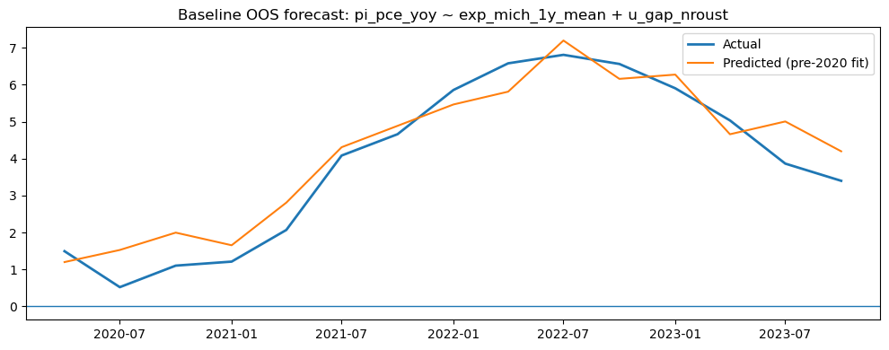

```python
d = baseline["dtest"]  # contains date, y, yhat, err for the rows used in the OOS evaluation

plt.figure(figsize=(10,4))
plt.plot(d["date"], d[y_var], label="Actual", linewidth=2)
plt.plot(d["date"], d["yhat"], label="Predicted (pre-2020 fit)")
plt.axhline(0, linewidth=1)
plt.title(f"Baseline OOS forecast: {y_var} ~ " + " + ".join(x_baseline))
plt.legend()
plt.tight_layout()
plt.show()
```

**Baseline out-of-sample fit (visual).**  
This plot compares actual post-pandemic inflation $\pi_t$ to the prediction $\hat{\pi}_t$ produced by the **pre-2020** estimated Phillips curve.  
A systematic and persistent gap (especially in 2021–2022) would be evidence of “failure to predict” in an out-of-sample forecasting sense.

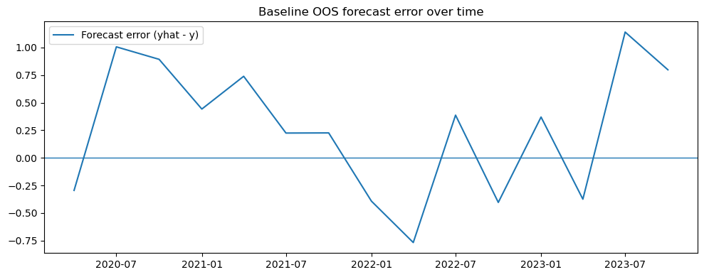

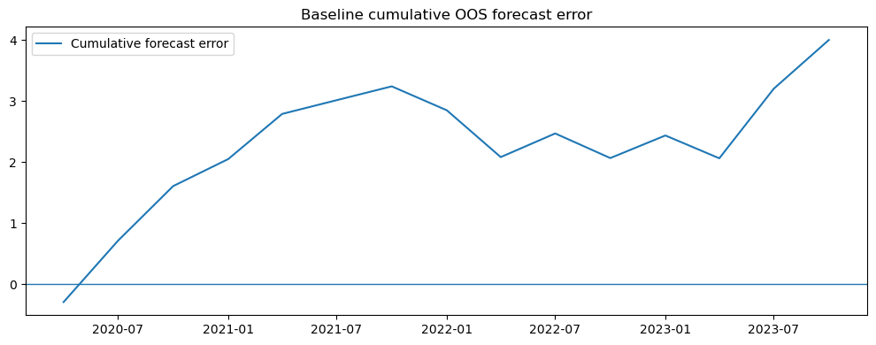

```python
d = baseline["dtest"].copy()

# Cumulative forecast error helps detect systematic under/over-prediction
d["cum_err"] = d["err"].cumsum()

fig, ax = plt.subplots(figsize=(10,4))
ax.plot(d["date"], d["err"], label="Forecast error (yhat - y)")
ax.axhline(0, linewidth=1)
ax.set_title("Baseline OOS forecast error over time")
ax.legend()
plt.tight_layout()
plt.show()

plt.figure(figsize=(10,4))
plt.plot(d["date"], d["cum_err"], label="Cumulative forecast error")
plt.axhline(0, linewidth=1)
plt.title("Baseline cumulative OOS forecast error")
plt.legend()
plt.tight_layout()
plt.show()
```

Baseline forecast errors (what the Phillips curve gets wrong). Define the out-of-sample forecast error as $e_t = \hat{\pi}_t - \pi_t$, where $\hat{\pi}_t$ is predicted using coefficients estimated on the pre-2020 sample and realized post-2020 RHS values.

Phase 1 (2020–early 2021): overprediction. Early in the pandemic window, $e_t > 0$: the model predicts higher inflation than realized inflation. This is consistent with the sharp disinflation in 2020 not being well captured by the baseline mapping from expectations and slack alone (and/or unusual pandemic-era dynamics in prices).

the relevant expectations measure differs from what is used here (measurement issue), and/or

the slope or intercept changed (instability in coefficients).

This motivates the next specifications: adding observable supply proxies (e.g., energy inflation) and swapping expectations measures to see whether the “failure” is robust or largely a measurement/omitted-variable problem.

```python
# --- Cell F (replacement): Expectations horse race with automatic availability checks ---

slack = "u_gap_nroust"
y_var = "pi_pce_yoy"

def available(varname: str) -> bool:
    """Return True if var exists and has at least one non-missing observation."""
    return (varname in df_full.columns) and df_full[varname].notna().any()

# Candidate expectations proxies (only those available will be used)
expectations_candidates = [
    ("Michigan median", "exp_mich_1y_median"),
    ("Michigan mean",   "exp_mich_1y_mean"),
    ("SPF 1y",          "exp_spf_1y"),
    ("Swap 1y",         "exp_swap_1y"),
]

expectations_list = [(lab, var) for lab, var in expectations_candidates if available(var)]
print("Using expectations series:", expectations_list)

rows = []
preds = {}

for label, exp_var in expectations_list:
    x = [exp_var, slack]
    out = oos_eval(df_train, df_test_common, y_var, x, hac_lags=4)

    m = out["metrics"]
    dtrain_used = out["dtrain"]

    rows.append({
        "expectations": label,
        "exp_var": exp_var,
        "slack": slack,
        "train_start": dtrain_used["period_q"].min(),
        "train_end":   dtrain_used["period_q"].max(),
        "train_N":     m["train_N"],
        "test_start":  out["dtest"]["period_q"].min() if len(out["dtest"]) else None,
        "test_end":    out["dtest"]["period_q"].max() if len(out["dtest"]) else None,
        "test_N":      m["test_N"],
        "rmse":        m["rmse"],
        "mae":         m["mae"],
        "bias":        m["bias"],
    })

    preds[label] = out["dtest"][["date", "period_q", y_var, "yhat"]].copy()

perf = pd.DataFrame(rows).sort_values("rmse")
perf
```

```
Using expectations series: [('Michigan median', 'exp_mich_1y_median'), ('Michigan mean', 'exp_mich_1y_mean'), ('SPF 1y', 'exp_spf_1y'), ('Swap 1y', 'exp_swap_1y')]
```

|  | expectations | exp_var | slack | train_start | train_end | train_N | test_start | test_end | test_N | rmse | mae | bias |
| --- | --- | --- | --- | --- | --- | --- | --- | --- | --- | --- | --- | --- |
| 1 | Michigan mean | exp_mich_1y_mean | u_gap_nroust | 1969Q1 | 2019Q4 | 204 | 2020Q1 | 2023Q3 | 15 | 0.633146 | 0.564113 | 0.266667 |
| 0 | Michigan median | exp_mich_1y_median | u_gap_nroust | 1978Q1 | 2019Q4 | 168 | 2020Q1 | 2023Q3 | 15 | 1.192549 | 1.020345 | -0.490756 |
| 3 | Swap 1y | exp_swap_1y | u_gap_nroust | 2004Q3 | 2019Q4 | 62 | 2020Q1 | 2023Q3 | 15 | 2.003002 | 1.658197 | -1.446655 |
| 2 | SPF 1y | exp_spf_1y | u_gap_nroust | 1981Q3 | 2019Q4 | 154 | 2020Q1 | 2023Q3 | 15 | 2.487187 | 2.048549 | -1.861308 |

**Expectations measurement horse race (robust to data availability).**  
Some expectations series have shorter sample coverage (e.g., inflation swaps typically begin in the mid-2000s), and some series may not be present (e.g., Michigan mean vs median depending on the dataset build).  
To avoid hard-coding, we include only expectations variables that exist and have non-missing observations.

For each expectations proxy, we estimate the Phillips curve on the available pre-2020 training sample and evaluate out-of-sample prediction performance over the common post-pandemic test window (2020Q1–2023Q3).  
We report training sample start/end dates and $N$ to make differences in data coverage transparent.

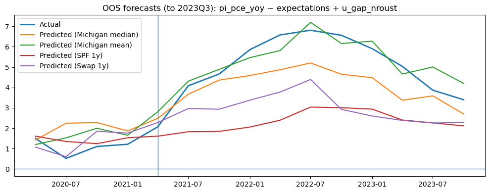

```python
import matplotlib.pyplot as plt

# Choose the prediction dataframe with the most rows as the base for "Actual"
base_label = max(preds.keys(), key=lambda k: len(preds[k]))
actual_df = preds[base_label].copy()

plt.figure(figsize=(10,4))

# Actual series
plt.plot(actual_df["date"], actual_df[y_var], label="Actual", linewidth=2)

# Predicted series for each expectations proxy
for label, d in preds.items():
    plt.plot(d["date"], d["yhat"], label=f"Predicted ({label})")

# visual marker around when inflation takes off
try:
    vline_date = df_test_common.loc[df_test_common["period_q"] == pd.Period("2021Q1", freq="Q"), "date"].iloc[0]
    plt.axvline(vline_date, linewidth=1)
except Exception:
    pass

plt.axhline(0, linewidth=1)
plt.title(f"OOS forecasts (to {TEST_END}): {y_var} ~ expectations + {slack}")
plt.legend()
plt.tight_layout()
plt.show()
```

**Overlay plot: predicted inflation paths by expectations proxy.**  
This figure holds the slack measure fixed and varies only the expectations proxy $\pi^e_t$.  
Each predicted line uses coefficients estimated on the pre-2020 training sample available for that expectations series (e.g., swaps may imply a shorter training window).  
Visual differences, especially during the 2021–2022 inflation surge indicate whether “Phillips curve failure” is primarily about the choice of expectations measure rather than a breakdown of the slack–inflation relationship.

### **Robustness Checks: Common training window/Michigan mean vs median wedge**

```python
# --- Robustness 1: Restrict training window to 2004Q1–2019Q4 for ALL expectations measures ---

TRAIN_START_RESTRICTED = pd.Period("2004Q1", freq="Q")
df_train_2004 = df_train[df_train["period_q"] >= TRAIN_START_RESTRICTED].copy()

print("Restricted train window:", df_train_2004["period_q"].min(), "to", df_train_2004["period_q"].max(),
      "| N =", len(df_train_2004))

slack = "u_gap_nroust"
y_var = "pi_pce_yoy"

def available(varname: str) -> bool:
    return (varname in df_full.columns) and df_full[varname].notna().any()

expectations_candidates = [
    ("Michigan median", "exp_mich_1y_median"),
    ("Michigan mean",   "exp_mich_1y_mean"),
    ("SPF 1y",          "exp_spf_1y"),
    ("Swap 1y",         "exp_swap_1y"),
]
expectations_list = [(lab, var) for lab, var in expectations_candidates if available(var)]
print("Using expectations series:", expectations_list)

rows_restricted = []
preds_restricted = {}

for label, exp_var in expectations_list:
    x = [exp_var, slack]
    out = oos_eval(df_train_2004, df_test_common, y_var, x, hac_lags=4)

    m = out["metrics"]
    dtrain_used = out["dtrain"]

    rows_restricted.append({
        "expectations": label,
        "exp_var": exp_var,
        "slack": slack,
        "train_start": dtrain_used["period_q"].min(),
        "train_end":   dtrain_used["period_q"].max(),
        "train_N":     m["train_N"],
        "test_start":  out["dtest"]["period_q"].min() if len(out["dtest"]) else None,
        "test_end":    out["dtest"]["period_q"].max() if len(out["dtest"]) else None,
        "test_N":      m["test_N"],
        "rmse":        m["rmse"],
        "mae":         m["mae"],
        "bias":        m["bias"],
    })

    preds_restricted[label] = out["dtest"][["date", "period_q", y_var, "yhat"]].copy()

perf_restricted = pd.DataFrame(rows_restricted).sort_values("rmse")
perf_restricted
```

```
Restricted train window: 2004Q1 to 2019Q4 | N = 64
Using expectations series: [('Michigan median', 'exp_mich_1y_median'), ('Michigan mean', 'exp_mich_1y_mean'), ('SPF 1y', 'exp_spf_1y'), ('Swap 1y', 'exp_swap_1y')]
```

|  | expectations | exp_var | slack | train_start | train_end | train_N | test_start | test_end | test_N | rmse | mae | bias |
| --- | --- | --- | --- | --- | --- | --- | --- | --- | --- | --- | --- | --- |
| 1 | Michigan mean | exp_mich_1y_mean | u_gap_nroust | 2004Q1 | 2019Q4 | 64 | 2020Q1 | 2023Q3 | 15 | 0.718758 | 0.615468 | -0.465068 |
| 0 | Michigan median | exp_mich_1y_median | u_gap_nroust | 2004Q1 | 2019Q4 | 64 | 2020Q1 | 2023Q3 | 15 | 1.107839 | 0.933580 | -0.933580 |
| 2 | SPF 1y | exp_spf_1y | u_gap_nroust | 2004Q1 | 2019Q4 | 64 | 2020Q1 | 2023Q3 | 15 | 1.270901 | 0.899365 | -0.526568 |
| 3 | Swap 1y | exp_swap_1y | u_gap_nroust | 2004Q3 | 2019Q4 | 62 | 2020Q1 | 2023Q3 | 15 | 2.003002 | 1.658197 | -1.446655 |

**Robustness 1: common training window (2004Q1–2019Q4).**  
Inflation swaps are only available starting in the mid-2000s, so swap-based Phillips curves are estimated on a shorter training sample by construction.  
To make expectations proxies comparable, we re-estimate all models on a common restricted training window (2004Q1–2019Q4) and re-rank out-of-sample performance over 2020Q1–2023Q3.

```
Missing columns: []
Wedge summary (overall):
count    183.000000
mean       0.895993
std        0.455889
min        0.066667
25%        0.566667
50%        0.800000
75%        1.183333
max        2.566667
Name: wedge_mean_minus_median, dtype: float64
```

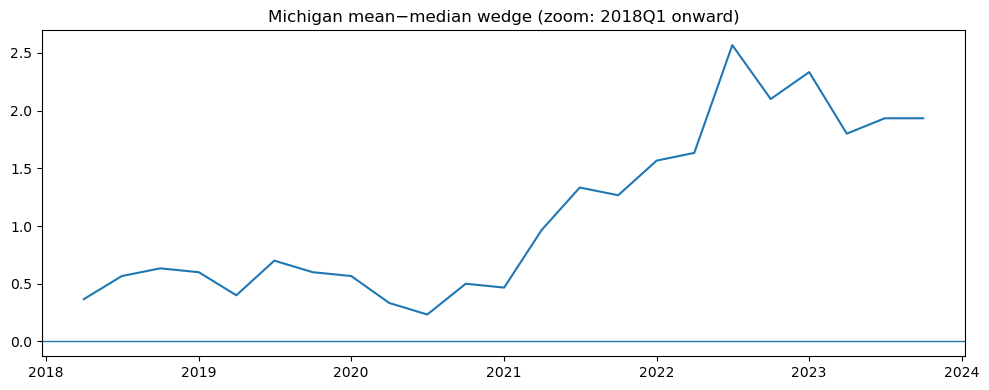

```python
# --- Robustness 2: Michigan mean vs median wedge diagnostics ---

need = ["date", "period_q", "exp_mich_1y_mean", "exp_mich_1y_median"]
missing = [c for c in need if c not in df_full.columns]
print("Missing columns:", missing)

dm = df_full[need].dropna().copy()
dm["wedge_mean_minus_median"] = dm["exp_mich_1y_mean"] - dm["exp_mich_1y_median"]

print("Wedge summary (overall):")
print(dm["wedge_mean_minus_median"].describe())

# Plot wedge over time, zoom on 2018+

dm_recent = dm[dm["period_q"] >= pd.Period("2018Q1", freq="Q")].copy()
plt.figure(figsize=(10,4))
plt.plot(dm_recent["date"], dm_recent["wedge_mean_minus_median"])
plt.axhline(0, linewidth=1)
plt.title("Michigan mean−median wedge (zoom: 2018Q1 onward)")
plt.tight_layout()
plt.show()
```

**Robustness 2: Michigan mean vs median.**  
Michigan provides both a mean and a median 1-year inflation expectation. The mean can be influenced by the upper tail of respondents’ beliefs, while the median is more robust to outliers.  
To understand why the mean may fit post-2020 inflation better, we plot the wedge $(\text{mean} - \text{median})$ over time and check whether it expands during the inflation surge (2021–2022).

### Baseline out-of-sample results (2020Q1–2023Q3): fit, errors, and the role of expectations

We begin by estimating an expectations-augmented Phillips curve on the pre-pandemic sample (1968Q1–2019Q4) and evaluating its out-of-sample (OOS) performance over 2020Q1–2023Q3 using a static/conditional forecast design: $$\pi_t = \alpha + \beta\,\pi^e_t + \kappa\,slack_t + \varepsilon_t,$$ where $\pi_t$ is PCE y/y inflation and $slack_t$ is the unemployment gap.

**Expectations horse race (holding slack fixed).**  
A key result is that the extent of “failure” depends strongly on which proxy is used for expected inflation $\pi^e_t$. Re-estimating the same pre-2020 Phillips curve while swapping only the expectations measure shows that **Michigan household expectations (mean and median)** deliver the closest tracking of post-pandemic inflation, while **SPF professional forecasts** and **inflation swaps** perform worse in the baseline specification. Thus, the apparent breakdown of the Phillips curve is partly an **expectations-measurement issue**: the same reduced-form relationship can look substantially better or worse depending on how $\pi^e_t$ is measured.

**Interpretation and next step.**  
Taken together, these baseline results show that a simple pre-2020 Phillips curve does not perfectly predict post-pandemic inflation, but the degree of failure is not invariant: it depends importantly on the expectations proxy and, potentially, on omitted factors. Importantly, these exercises do **not** yet establish that the unemployment–inflation relationship (the slack coefficient $\kappa$) changed after COVID; they motivate extending the specification (e.g., adding observable supply/cost controls such as energy inflation) and then directly testing whether $\kappa$ is stable in the post-2020 period.

#### **Plot used in paper**

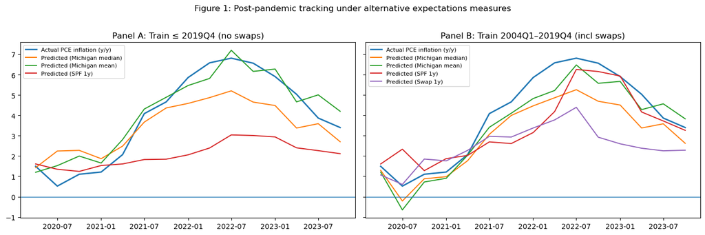

```python
# ---- Exhibit 1: two-panel expectations tracking plot (REUSE preds + preds_restricted) ----

y_var = "pi_pce_yoy"

# Sanity checks
assert "preds" in globals(), "preds not found. Run Cell 19 first (expectations horse race)."
assert "preds_restricted" in globals(), "preds_restricted not found. Run Cell 24 first (restricted 2004Q1–2019Q4)."

# Helper: pick an 'actual' series from any one of the stored dfs
def get_actual(pred_dict, y_var):
    # pick first entry
    first_key = list(pred_dict.keys())[0]
    d = pred_dict[first_key].copy()
    return d[["date", y_var]].drop_duplicates()

# -------- Panel A: full pre-2020 train, exclude swaps (so it’s “long sample” expectations) --------
actual_A = get_actual(preds, y_var)

panelA_labels = [k for k in preds.keys() if "Swap" not in k]  # exclude swaps for Panel A

# -------- Panel B: restricted train window (2004Q1–2019Q4), include swaps --------
actual_B = get_actual(preds_restricted, y_var)
panelB_labels = list(preds_restricted.keys())  # include Swap if present

# -------- Plot --------
fig, axes = plt.subplots(1, 2, figsize=(14, 4.5), sharey=True)

# Panel A
ax = axes[0]
ax.plot(actual_A["date"], actual_A[y_var], label="Actual PCE inflation (y/y)", linewidth=2)
for lab in panelA_labels:
    ax.plot(preds[lab]["date"], preds[lab]["yhat"], label=f"Predicted ({lab})")
ax.set_title("Panel A: Train ≤ 2019Q4 (no swaps)")
ax.axhline(0, linewidth=1)
ax.legend(fontsize=8)

# Panel B
ax = axes[1]
ax.plot(actual_B["date"], actual_B[y_var], label="Actual PCE inflation (y/y)", linewidth=2)
for lab in panelB_labels:
    ax.plot(preds_restricted[lab]["date"], preds_restricted[lab]["yhat"], label=f"Predicted ({lab})")
ax.set_title("Panel B: Train 2004Q1–2019Q4 (incl swaps)")
ax.axhline(0, linewidth=1)
ax.legend(fontsize=8)

plt.suptitle("Figure 1: Post-pandemic tracking under alternative expectations measures", y=1.02)
plt.tight_layout()
plt.show()
```

## **Analysis Section 2: Considering the forecasting power of OOS tests**

### **Test 1: Benchmark Comparison**

```python
# --- Benchmark comparison setup ---

# Uses our existing variables:
# y_var (e.g. "pi_pce_yoy"), TEST_END (2023Q3 Period), df_test_common, df_full, df_train
# baseline = oos_eval(...) from earlier

# 1) Build a time-sorted series for inflation to create lag-based benchmarks
ts = df_full[["period_q", "date", y_var]].sort_values("period_q").copy()

ts["pi_l1"] = ts[y_var].shift(1)                      # random-walk benchmark
ts["pi_ma4"] = ts[y_var].shift(1).rolling(4).mean()   # trailing 4-quarter average benchmark

# Restrict to the common test window
ts_test = ts[(ts["period_q"] >= df_test_common["period_q"].min()) &
             (ts["period_q"] <= TEST_END)].copy()

# 2) Merge in baseline Phillips curve predictions (already OOS and dropna-ed)
pc_pred = baseline["dtest"][["period_q", "yhat"]].copy().rename(columns={"yhat": "pi_hat_pc"})
eval_df = ts_test.merge(pc_pred, on="period_q", how="left")

# 3) Keep rows where we have the dependent variable and all benchmark forecasts
# (PC predictions may be missing in a quarter if regressors were missing)
eval_df = eval_df.dropna(subset=[y_var, "pi_hat_pc", "pi_l1", "pi_ma4"]).copy()

print("Evaluation window used:", eval_df["period_q"].min(), "to", eval_df["period_q"].max())
print("N used for benchmark comparison:", len(eval_df))
eval_df.head()
```

```
Evaluation window used: 2020Q1 to 2023Q3
N used for benchmark comparison: 15
```

|  | period_q | date | pi_pce_yoy | pi_l1 | pi_ma4 | pi_hat_pc |
| --- | --- | --- | --- | --- | --- | --- |
| 0 | 2020Q1 | 2020-03-31 23:59:59.999999999 | 1.495308 | 1.400986 | 1.437159 | 1.200827 |
| 1 | 2020Q2 | 2020-06-30 23:59:59.999999999 | 0.521810 | 1.495308 | 1.441665 | 1.528293 |
| 2 | 2020Q3 | 2020-09-30 23:59:59.999999999 | 1.104420 | 0.521810 | 1.201700 | 1.997811 |
| 3 | 2020Q4 | 2020-12-31 23:59:59.999999999 | 1.213169 | 1.104420 | 1.130631 | 1.656025 |
| 4 | 2021Q1 | 2021-03-31 23:59:59.999999999 | 2.070571 | 1.213169 | 1.083677 | 2.810217 |

**Benchmark forecasts (why do this?).**  
Out-of-sample “failure” is more informative when compared to simple inflation-forecast benchmarks.  
Here we construct three benchmarks that use only lagged inflation information: a no-change forecast $\hat{\pi}_t=\pi_{t-1}$, a trailing 4-quarter average, and an AR(1) estimated on the pre-2020 training sample.  
We then compare these to the baseline Phillips-curve forecast over the common test window (2020Q1–2023Q3).

```python
# --- AR(1) benchmark estimated on pre-2020 train sample ---

# Build lagged inflation in the train sample
train_ts = df_train[["period_q", y_var]].sort_values("period_q").copy()
train_ts["pi_l1"] = train_ts[y_var].shift(1)

train_ar = train_ts.dropna(subset=[y_var, "pi_l1"]).copy()
X_ar = sm.add_constant(train_ar["pi_l1"])
Y_ar = train_ar[y_var]

# Plain OLS is fine for benchmark; HAC also ok (doesn't matter much for forecasting)
ar_res = sm.OLS(Y_ar, X_ar).fit(cov_type="HAC", cov_kwds={"maxlags": 4})
print(ar_res.summary())

# Predict AR(1) on the eval_df rows (needs pi_l1)
eval_df["pi_hat_ar1"] = ar_res.predict(sm.add_constant(eval_df["pi_l1"], has_constant="add"))
```

```
                            OLS Regression Results
==============================================================================
Dep. Variable:             pi_pce_yoy   R-squared:                       0.950
Model:                            OLS   Adj. R-squared:                  0.950
Method:                 Least Squares   F-statistic:                     961.0
Date:                Mon, 26 Jan 2026   Prob (F-statistic):           1.61e-78
Time:                        13:19:38   Log-Likelihood:                -172.22
No. Observations:                 203   AIC:                             348.4
Df Residuals:                     201   BIC:                             355.1
Df Model:                           1
Covariance Type:                  HAC
==============================================================================
                 coef    std err          z      P>|z|      [0.025      0.975]
------------------------------------------------------------------------------
const          0.0694      0.087      0.800      0.423      -0.101       0.240
pi_l1          0.9764      0.031     31.000      0.000       0.915       1.038
==============================================================================
Omnibus:                       23.971   Durbin-Watson:                   1.083
Prob(Omnibus):                  0.000   Jarque-Bera (JB):              119.342
Skew:                           0.067   Prob(JB):                     1.22e-26
Kurtosis:                       6.754   Cond. No.                         7.70
==============================================================================

Notes:
[1] Standard Errors are heteroscedasticity and autocorrelation robust (HAC) using 4 lags and without small sample correction
```

**AR(1) benchmark.**
We estimate an AR(1) model of inflation on the pre-2020 training sample, $$\pi_t = a + \rho\,\pi_{t-1} + u_t,$$ and generate OOS predictions in the test window using only lagged inflation. This provides a standard low-information benchmark for inflation forecasting.

```python
def forecast_metrics(y_true, y_hat):
    err = y_hat - y_true
    return {
        "RMSE": float(np.sqrt(np.mean(err**2))),
        "MAE":  float(np.mean(np.abs(err))),
        "Bias": float(np.mean(err))
    }

y = eval_df[y_var]

results = []
for name, col in [
    ("Phillips curve (baseline)", "pi_hat_pc"),
    ("Naive no-change (pi_{t-1})", "pi_l1"),
    ("Trailing mean (4q)", "pi_ma4"),
    ("AR(1) benchmark", "pi_hat_ar1"),
]:
    m = forecast_metrics(y, eval_df[col])
    results.append({"model": name, **m})

bench_table = pd.DataFrame(results).sort_values("RMSE")
bench_table
```

|  | model | RMSE | MAE | Bias |
| --- | --- | --- | --- | --- |
| 0 | Phillips curve (baseline) | 0.633146 | 0.564113 | 0.266667 |
| 3 | AR(1) benchmark | 0.856432 | 0.700365 | -0.153881 |
| 1 | Naive no-change (pi_{t-1}) | 0.866855 | 0.717684 | -0.133281 |
| 2 | Trailing mean (4q) | 1.713730 | 1.402523 | -0.449346 |

**Forecasting power in OOS: does the Phillips curve beat simple benchmarks?**  
RMSE/MAE compare overall accuracy; Bias summarizes systematic under- or over-prediction.  
If the baseline Phillips curve does not outperform simple lag-inflation benchmarks, then “failure to predict” may reflect the general difficulty of forecasting inflation rather than a uniquely post-COVID breakdown of the slack–inflation relationship.

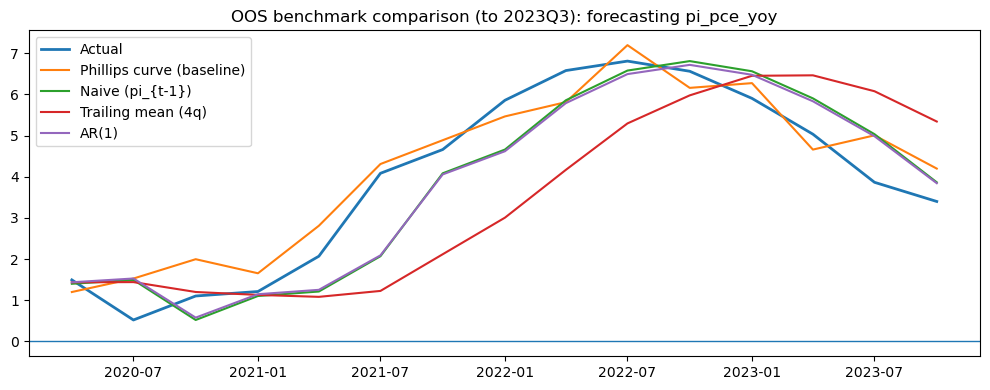

```python
plt.figure(figsize=(10,4))
plt.plot(eval_df["date"], eval_df[y_var], label="Actual", linewidth=2)
plt.plot(eval_df["date"], eval_df["pi_hat_pc"], label="Phillips curve (baseline)")
plt.plot(eval_df["date"], eval_df["pi_l1"], label="Naive (pi_{t-1})")
plt.plot(eval_df["date"], eval_df["pi_ma4"], label="Trailing mean (4q)")
plt.plot(eval_df["date"], eval_df["pi_hat_ar1"], label="AR(1)")
plt.axhline(0, linewidth=1)
plt.title(f"OOS benchmark comparison (to {TEST_END}): forecasting {y_var}")
plt.legend()
plt.tight_layout()
plt.show()
```

### OOS benchmark comparison: does the baseline Phillips curve add forecasting value?

To assess forecasting power, we compare the baseline Phillips-curve OOS forecast to simple inflation-only benchmarks that use only lagged inflation information: a no-change forecast ($\hat{\pi}_t=\pi_{t-1}$), a trailing 4-quarter mean, and an AR(1) estimated on the pre-2020 training sample.

### **Test 2: Longer-window pseudo-OOS to show “COVID isn’t the only hard part” (or “COVID is uniquely hard”)**

```python
# --- Longer-window pseudo-OOS benchmark comparison ---

# -----------------------
# 1) Prepare time series with benchmark predictors
# -----------------------
ts = df_full[["period_q", "date", y_var]].sort_values("period_q").copy()

# Benchmarks based only on lagged inflation information
ts["pi_l1"]  = ts[y_var].shift(1)                    # naive no-change: pi_{t-1}
ts["pi_ma4"] = ts[y_var].shift(1).rolling(4).mean()  # trailing 4-quarter mean

def forecast_metrics(y_true, y_hat):
    err = y_hat - y_true
    return {
        "RMSE": float(np.sqrt(np.mean(err**2))),
        "MAE":  float(np.mean(np.abs(err))),
        "Bias": float(np.mean(err)),
        "N":    int(len(err))
    }

def eval_benchmarks_one_window(ts, y, train_start, train_end, test_start, test_end, label, hac_lags=4):
    """
    Evaluate three inflation-only benchmarks in a given train/test window:
      (i) naive no-change (pi_{t-1})
      (ii) trailing 4-quarter mean
      (iii) AR(1) estimated on the train window
    """
    # --- Train sample for AR(1)
    train = ts[(ts["period_q"] >= train_start) & (ts["period_q"] <= train_end)].copy()
    train = train.dropna(subset=[y, "pi_l1"])

    Xtr = sm.add_constant(train["pi_l1"])
    ytr = train[y]
    ar1 = sm.OLS(ytr, Xtr).fit(cov_type="HAC", cov_kwds={"maxlags": hac_lags})

    # --- Test/evaluation sample (needs lag-based forecasts available)
    test = ts[(ts["period_q"] >= test_start) & (ts["period_q"] <= test_end)].copy()
    test = test.dropna(subset=[y, "pi_l1", "pi_ma4"]).copy()

    # Forecasts
    test["f_naive"] = test["pi_l1"]
    test["f_ma4"]   = test["pi_ma4"]
    test["f_ar1"]   = ar1.predict(sm.add_constant(test["pi_l1"], has_constant="add"))

    # Metrics table
    rows = []
    for mname, col in [
        ("AR(1)", "f_ar1"),
        ("Naive no-change (pi_{t-1})", "f_naive"),
        ("Trailing mean (4q)", "f_ma4"),
    ]:
        met = forecast_metrics(test[y], test[col])
        rows.append({
            "window": label,
            "model": mname,
            **met
        })

    metrics_df = pd.DataFrame(rows).sort_values("RMSE")
    return metrics_df, test, ar1

# -----------------------
# 2) Define the three windows (Periods)
# -----------------------
W1 = dict(
    label="Train 1968–2007, Test 2008–2019",
    train_start=pd.Period("1968Q1", freq="Q"),
    train_end=pd.Period("2007Q4", freq="Q"),
    test_start=pd.Period("2008Q1", freq="Q"),
    test_end=pd.Period("2019Q4", freq="Q"),
)

W2 = dict(
    label="Train 1968–2019, Test 2020–2023Q3",
    train_start=pd.Period("1968Q1", freq="Q"),
    train_end=pd.Period("2019Q4", freq="Q"),
    test_start=pd.Period("2020Q1", freq="Q"),
    test_end=pd.Period("2023Q3", freq="Q"),
)

W3 = dict(
    label="Train 1968–2007, Test 2008–2023Q3",
    train_start=pd.Period("1968Q1", freq="Q"),
    train_end=pd.Period("2007Q4", freq="Q"),
    test_start=pd.Period("2008Q1", freq="Q"),
    test_end=pd.Period("2023Q3", freq="Q"),
)

windows = [W1, W2, W3]

# -----------------------
# 3) Run all windows and stack results
# -----------------------
all_metrics = []
tests = {}     # store the evaluation dataframes (for plots)
ar_models = {} # store AR(1) fitted models (optional)

for w in windows:
    met, test_df, ar1 = eval_benchmarks_one_window(
        ts, y_var, w["train_start"], w["train_end"], w["test_start"], w["test_end"], w["label"], hac_lags=4
    )
    all_metrics.append(met)
    tests[w["label"]] = test_df
    ar_models[w["label"]] = ar1

bench_3win = pd.concat(all_metrics, ignore_index=True)
bench_3win
```

|  | window | model | RMSE | MAE | Bias | N |
| --- | --- | --- | --- | --- | --- | --- |
| 0 | Train 1968–2007, Test 2008–2019 | AR(1) | 0.675686 | 0.422451 | 0.091374 | 48 |
| 1 | Train 1968–2007, Test 2008–2019 | Naive no-change (pi_{t-1}) | 0.678798 | 0.419344 | 0.041369 | 48 |
| 2 | Train 1968–2007, Test 2008–2019 | Trailing mean (4q) | 1.056227 | 0.739481 | 0.067181 | 48 |
| 3 | Train 1968–2019, Test 2020–2023Q3 | AR(1) | 0.856432 | 0.700365 | -0.153881 | 15 |
| 4 | Train 1968–2019, Test 2020–2023Q3 | Naive no-change (pi_{t-1}) | 0.866855 | 0.717684 | -0.133281 | 15 |
| 5 | Train 1968–2019, Test 2020–2023Q3 | Trailing mean (4q) | 1.713730 | 1.402523 | -0.449346 | 15 |
| 6 | Train 1968–2007, Test 2008–2023Q3 | AR(1) | 0.722129 | 0.488061 | 0.038283 | 63 |
| 7 | Train 1968–2007, Test 2008–2023Q3 | Naive no-change (pi_{t-1}) | 0.727993 | 0.490378 | -0.000214 | 63 |
| 8 | Train 1968–2007, Test 2008–2023Q3 | Trailing mean (4q) | 1.244687 | 0.897348 | -0.055802 | 63 |

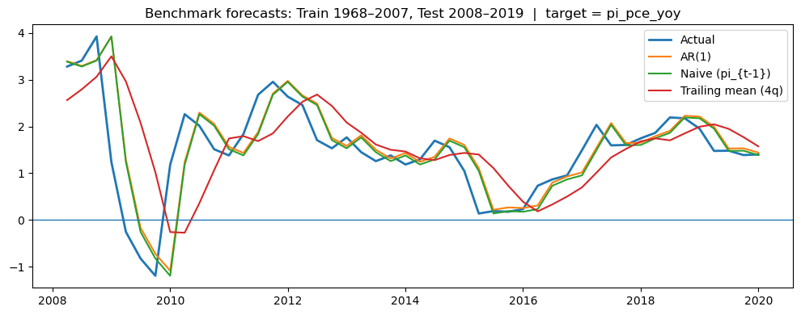

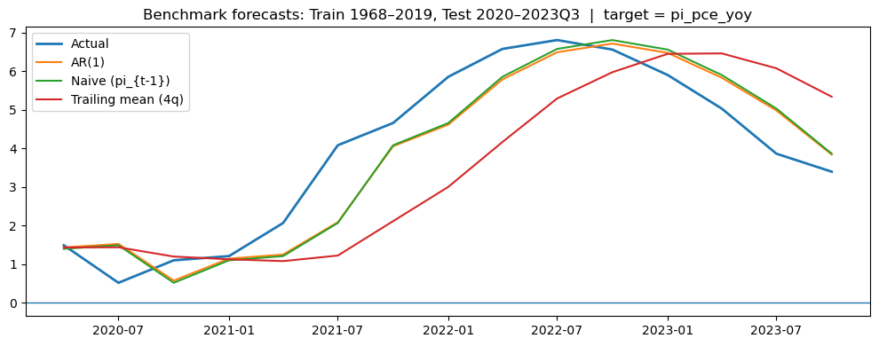

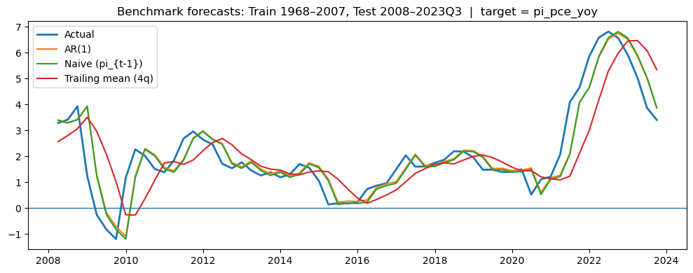

```python
for label, d in tests.items():
    plt.figure(figsize=(10,4))
    plt.plot(d["date"], d[y_var], label="Actual", linewidth=2)
    plt.plot(d["date"], d["f_ar1"], label="AR(1)")
    plt.plot(d["date"], d["f_naive"], label="Naive (pi_{t-1})")
    plt.plot(d["date"], d["f_ma4"], label="Trailing mean (4q)")
    plt.axhline(0, linewidth=1)
    plt.title(f"Benchmark forecasts: {label}  |  target = {y_var}")
    plt.legend()
    plt.tight_layout()
    plt.show()
```

### Forecasting-difficulty check: benchmark performance across multiple OOS windows

We evaluate three inflation-only benchmark forecasts:

- **Naive no-change:** $\hat{\pi}_t=\pi_{t-1}$
- **Trailing mean (4 quarters):** $\hat{\pi}_t=\frac{1}{4}\sum_{j=1}^{4}\pi_{t-j}$
- **AR(1):** $\pi_t=a+\rho\pi_{t-1}+u_t$ estimated on the training sample

We compute RMSE/MAE/bias in three windows:

1. Train 1968–2007, test 2008–2019 (post-GFC era)
2. Train 1968–2019, test 2020–2023Q3 (COVID inflation era)
3. Train 1968–2007, test 2008–2023Q3 (long stress test)

This establishes a disciplined baseline: if simple persistence benchmarks perform very well (or if their performance varies sharply by window), then “failed to predict” should not be interpreted as uniquely about the Phillips curve without further evidence.

### Forecasting-difficulty results: benchmark performance across three OOS windows (and limitations)

We evaluate three inflation-only benchmark forecasts—AR(1), naive no-change ($\hat{\pi}_t=\pi_{t-1}$), and a trailing 4-quarter mean—across three pseudo out-of-sample (OOS) windows. The goal is to establish how difficult inflation forecasting is *even before* asking whether the Phillips curve “failed.”

**Key results.**

**Interpretation for the project question.**  
These results establish a baseline: *post-pandemic inflation is difficult to forecast even with simple time-series models*, and benchmark performance depends on the evaluation window. Therefore, claims that “the Phillips curve failed to predict inflation” should be interpreted relative to (i) how hard the episode is to forecast in general, and (ii) whether Phillips-curve variants can add predictive value beyond these strong benchmarks.

### Limitations and caveats (important for interpreting benchmark comparisons)

1. **Small post-pandemic evaluation sample (N=15).**  
   Forecast rankings in 2020–2023Q3 are based on a short window. Differences in RMSE can be noisy, and a few quarters can drive results. This is a key reason to also report longer-window evidence and to avoid over-interpreting small RMSE gaps.
2. **Pseudo-OOS and revised data.**  
   This is not a fully real-time forecasting exercise: we use revised inflation series and construct lagged predictors using the final dataset. Results are best interpreted as a diagnostic of predictability under a consistent data vintage rather than as a real-time forecasting competition.
3. **Horizon/target dependence.**  
   All results here are for the specific inflation target used (e.g., PCE y/y). Forecast difficulty and benchmark performance can change with alternative transformations (q/q annualized vs y/y) and alternative inflation measures (headline vs core). This motivates checking robustness across targets/horizons if space allows.
4. **Model simplicity and regime change.**  
   AR(1) and no-change implicitly assume a stable inflation process. The deterioration in performance when moving from 2008–2019 to 2020–2023 reflects regime change (pandemic shocks, reopening dynamics, energy, supply bottlenecks). Benchmark dominance does not imply “structure is irrelevant”; it shows that capturing these regime changes is the key forecasting challenge.
5. **Benchmark set is deliberately narrow.**  
   These are intentionally low-information models. The point is not that they are the best possible forecasts, but that they set a high bar: a Phillips curve specification should be judged by whether it improves meaningfully on these baselines.

### Test C: Forecast horizon sensitivity (1-step vs 4-step / y/y vs q/q)

```python
# -----------------------
# Test C: switch inflation target to QoQ annualized
# -----------------------
y_var_qoq = "pi_pce_qoq_ann"

# Prepare time series with benchmark predictors
ts_qoq = df_full[["period_q", "date", y_var_qoq]].sort_values("period_q").copy()

ts_qoq["pi_l1"]  = ts_qoq[y_var_qoq].shift(1)                    # naive: pi_{t-1}
ts_qoq["pi_ma4"] = ts_qoq[y_var_qoq].shift(1).rolling(4).mean()  # trailing 4q mean

def forecast_metrics(y_true, y_hat):
    err = y_hat - y_true
    return {
        "RMSE": float(np.sqrt(np.mean(err**2))),
        "MAE":  float(np.mean(np.abs(err))),
        "Bias": float(np.mean(err)),
        "N":    int(len(err))
    }

def eval_benchmarks_one_window(ts, y, train_start, train_end, test_start, test_end, label, hac_lags=4):
    # Train AR(1)
    train = ts[(ts["period_q"] >= train_start) & (ts["period_q"] <= train_end)].copy()
    train = train.dropna(subset=[y, "pi_l1"])

    Xtr = sm.add_constant(train["pi_l1"])
    ytr = train[y]
    ar1 = sm.OLS(ytr, Xtr).fit(cov_type="HAC", cov_kwds={"maxlags": hac_lags})

    # Test
    test = ts[(ts["period_q"] >= test_start) & (ts["period_q"] <= test_end)].copy()
    test = test.dropna(subset=[y, "pi_l1", "pi_ma4"]).copy()

    test["f_naive"] = test["pi_l1"]
    test["f_ma4"]   = test["pi_ma4"]
    test["f_ar1"]   = ar1.predict(sm.add_constant(test["pi_l1"], has_constant="add"))

    rows = []
    for mname, col in [
        ("AR(1)", "f_ar1"),
        ("Naive no-change (pi_{t-1})", "f_naive"),
        ("Trailing mean (4q)", "f_ma4"),
    ]:
        met = forecast_metrics(test[y], test[col])
        rows.append({"window": label, "model": mname, **met})

    metrics_df = pd.DataFrame(rows).sort_values("RMSE")
    return metrics_df, test, ar1

# Define the same three windows as before
W1 = dict(
    label="Train 1968–2007, Test 2008–2019",
    train_start=pd.Period("1968Q1", freq="Q"),
    train_end=pd.Period("2007Q4", freq="Q"),
    test_start=pd.Period("2008Q1", freq="Q"),
    test_end=pd.Period("2019Q4", freq="Q"),
)

W2 = dict(
    label="Train 1968–2019, Test 2020–2023Q3",
    train_start=pd.Period("1968Q1", freq="Q"),
    train_end=pd.Period("2019Q4", freq="Q"),
    test_start=pd.Period("2020Q1", freq="Q"),
    test_end=pd.Period("2023Q3", freq="Q"),
)

W3 = dict(
    label="Train 1968–2007, Test 2008–2023Q3",
    train_start=pd.Period("1968Q1", freq="Q"),
    train_end=pd.Period("2007Q4", freq="Q"),
    test_start=pd.Period("2008Q1", freq="Q"),
    test_end=pd.Period("2023Q3", freq="Q"),
)

windows = [W1, W2, W3]

# Run all windows and stack results
all_metrics_qoq = []
tests_qoq = {}

for w in windows:
    met, test_df, ar1 = eval_benchmarks_one_window(
        ts_qoq, y_var_qoq,
        w["train_start"], w["train_end"],
        w["test_start"], w["test_end"],
        w["label"],
        hac_lags=4
    )
    all_metrics_qoq.append(met)
    tests_qoq[w["label"]] = test_df

bench_3win_qoq = pd.concat(all_metrics_qoq, ignore_index=True)
bench_3win_qoq
```

|  | window | model | RMSE | MAE | Bias | N |
| --- | --- | --- | --- | --- | --- | --- |
| 0 | Train 1968–2007, Test 2008–2019 | AR(1) | 1.984947 | 1.210243 | 0.414309 | 48 |
| 1 | Train 1968–2007, Test 2008–2019 | Trailing mean (4q) | 2.080019 | 1.298381 | 0.099168 | 48 |
| 2 | Train 1968–2007, Test 2008–2019 | Naive no-change (pi_{t-1}) | 2.085460 | 1.289835 | 0.051758 | 48 |
| 3 | Train 1968–2019, Test 2020–2023Q3 | AR(1) | 1.801179 | 1.366553 | -0.178890 | 15 |
| 4 | Train 1968–2019, Test 2020–2023Q3 | Naive no-change (pi_{t-1}) | 1.936437 | 1.429420 | -0.080778 | 15 |
| 5 | Train 1968–2019, Test 2020–2023Q3 | Trailing mean (4q) | 2.243043 | 1.975741 | -0.273024 | 15 |
| 6 | Train 1968–2007, Test 2008–2023Q3 | AR(1) | 1.945526 | 1.246122 | 0.299919 | 63 |
| 7 | Train 1968–2007, Test 2008–2023Q3 | Naive no-change (pi_{t-1}) | 2.050961 | 1.323069 | 0.020202 | 63 |
| 8 | Train 1968–2007, Test 2008–2023Q3 | Trailing mean (4q) | 2.119972 | 1.459657 | 0.010551 | 63 |

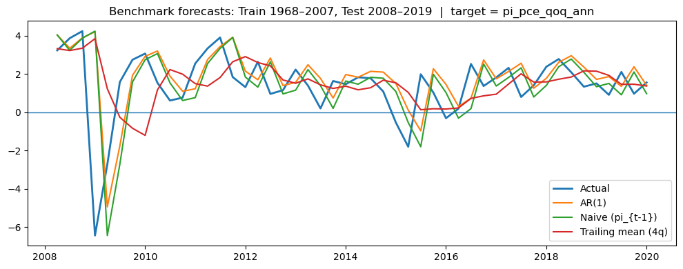

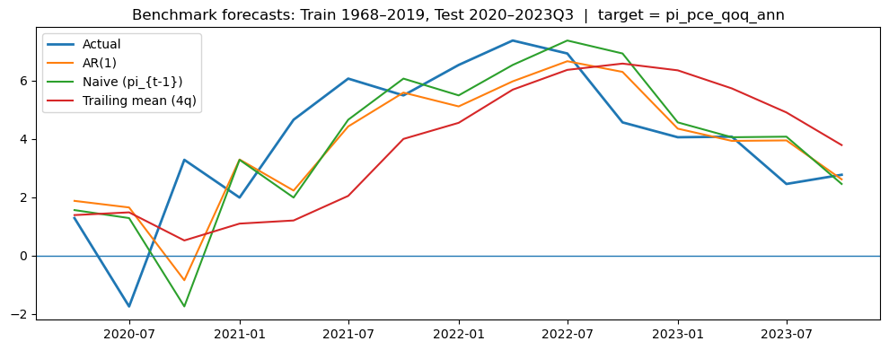

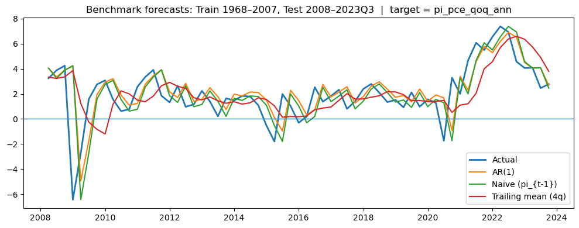

```python
for label, d in tests_qoq.items():
    plt.figure(figsize=(10,4))
    plt.plot(d["date"], d[y_var_qoq], label="Actual", linewidth=2)
    plt.plot(d["date"], d["f_ar1"], label="AR(1)")
    plt.plot(d["date"], d["f_naive"], label="Naive (pi_{t-1})")
    plt.plot(d["date"], d["f_ma4"], label="Trailing mean (4q)")
    plt.axhline(0, linewidth=1)
    plt.title(f"Benchmark forecasts: {label}  |  target = {y_var_qoq}")
    plt.legend()
    plt.tight_layout()
    plt.show()
```

### Test C: benchmark forecasting under an alternative inflation definition (q/q annualized)

Inflation forecasting results can depend on the choice of inflation definition. Year-on-year inflation is mechanically smoother (it averages over four quarters), while quarter-on-quarter annualized inflation places more weight on high-frequency movements and turning points.  
To ensure our benchmark conclusions are not an artifact of using a smoothed inflation series, we repeat the three-window benchmark comparison using **q/q annualized PCE inflation** ($\pi_t^{q/q,ann}$). This helps clarify whether “forecasting difficulty” is primarily about high-frequency volatility versus medium-horizon inflation dynamics.

### Test C conclusion: benchmark forecasting with q/q annualized inflation

Repeating the benchmark comparison using **q/q annualized PCE inflation** changes the level of forecast errors but reinforces the core message: **inflation is structurally difficult to forecast in pseudo-OOS tests, especially around turning points and high-volatility episodes.**

**What changes relative to y/y inflation.**  
q/q annualized inflation is much noisier than y/y inflation, so RMSEs are mechanically larger in every window. This is expected because q/q annualized inflation places full weight on quarter-to-quarter fluctuations rather than smoothing over four quarters.

**Interpretation for the broader project.**  
This exercise strengthens the forecasting-difficulty argument: even before introducing Phillips-curve structure, the data indicate that benchmark performance depends on the evaluation window and the inflation definition. Therefore, a claim that “the Phillips curve failed to predict inflation after the pandemic” should be judged relative to a demanding baseline—simple persistence forecasts that already struggle when inflation dynamics change sharply. This motivates the next section: testing whether specific Phillips-curve ingredients (expectations measures, slack definitions, and cost/supply controls) add forecasting value beyond these strong benchmarks.

### Summary: what OOS exercises imply about the difficulty of forecasting inflation

Before attributing post-pandemic forecast errors to a “breakdown” of the Phillips curve, we first assess how hard inflation is to forecast in pseudo out-of-sample (OOS) tests more generally.

**Benchmark contest (COVID window).**  
In the 2020Q1–2023Q3 evaluation window, simple persistence-based time-series benchmarks—especially an AR(1) and a naive no-change forecast—perform very well and can outperform a baseline Phillips-curve forecast. This indicates that the post-pandemic episode is not only challenging for Phillips-curve specifications; it is challenging for low-information forecasting rules in general.

**Window sensitivity (three OOS windows).**  
Benchmark performance is not stable across regimes. Forecast errors are materially smaller in the post-GFC low-inflation era (2008–2019) than in the COVID inflation era (2020–2023Q3), and a long stress-test window (2008–2023Q3) reflects the deterioration when the post-pandemic regime is included. This reinforces that pseudo-OOS conclusions are evaluation-window-dependent.

**Implication for the project question.**  
These results establish a demanding baseline for interpreting “Phillips curve failure”: post-pandemic inflation is difficult to forecast even with simple models, and OOS rankings depend on the window and inflation definition. Therefore, to make the claim that the Phillips curve “failed,” we need to show that *well-motivated* Phillips-curve variants (expectations measurement, slack definitions, and supply/cost controls) either (i) meaningfully improve OOS performance relative to these benchmarks or (ii) reveal instability specifically in the slack–inflation relationship rather than generic forecast difficulty.

```python
# Recompute PC forecast for Panel A with Michigan mean and overwrite eval_df column
pc_A_mean = oos_eval(df_train, df_test_common, y_var,
                     ["exp_mich_1y_mean", "u_gap_nroust"], hac_lags=4)
pc_pred_A = pc_A_mean["dtest"][["date", "period_q", "yhat"]].rename(columns={"yhat": "pi_hat_pc_new"})

# Merge by period_q (or date); then replace pi_hat_pc
eval_df = eval_df.drop(columns=["pi_hat_pc"], errors="ignore").merge(
    pc_pred_A[["period_q", "pi_hat_pc_new"]],
    on="period_q",
    how="left"
).rename(columns={"pi_hat_pc_new": "pi_hat_pc"})

eval_df[["period_q", "pi_hat_pc"]].head()
```

|  | period_q | pi_hat_pc |
| --- | --- | --- |
| 0 | 2020Q1 | 1.200827 |
| 1 | 2020Q2 | 1.528293 |
| 2 | 2020Q3 | 1.997811 |
| 3 | 2020Q4 | 1.656025 |
| 4 | 2021Q1 | 2.810217 |

#### **Plot used in paper**

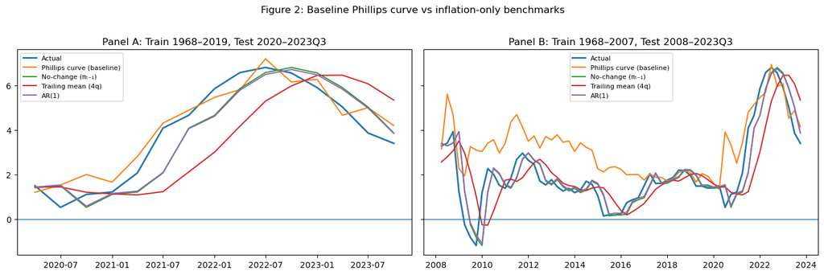

```
Panel A N: 15 | Panel B N: 63
```

```python
# --- prerequisites (already in the notebook)
# y_var, x_baseline, eval_df, df_full, oos_eval, tests

# -----------------------------
# Panel A: Train 1968–2019, Test 2020–2023Q3
# (You already built this as eval_df in the benchmark section)
# -----------------------------
assert "eval_df" in globals(), "eval_df not found. Run the benchmark comparison setup cell first."
panelA = eval_df.copy()

# -----------------------------
# Panel B: Train 1968–2007, Test 2008–2023Q3
# Benchmarks already stored in tests[...] from bench_3win.
# Add PC predictions and merge.
# -----------------------------
assert "tests" in globals(), "tests not found. Run the bench_3win cell first."

w3_label = "Train 1968–2007, Test 2008–2023Q3"
assert w3_label in tests, f"'{w3_label}' not found in tests. Check the exact window label."

panelB = tests[w3_label].copy()

# Build train/test dfs for the Phillips curve in this window
train_B = df_full[(df_full["period_q"] >= pd.Period("1968Q1", freq="Q")) &
                  (df_full["period_q"] <= pd.Period("2007Q4", freq="Q"))].copy()
test_B  = df_full[(df_full["period_q"] >= pd.Period("2008Q1", freq="Q")) &
                  (df_full["period_q"] <= pd.Period("2023Q3", freq="Q"))].copy()

pc_B = oos_eval(train_B, test_B, y_var, x_baseline, hac_lags=4)
pc_pred_B = pc_B["dtest"][["period_q", "date", "yhat"]].rename(columns={"yhat": "pi_hat_pc"})

# Merge PC into the benchmark dataframe (benchmarks are in panelB already)
panelB = panelB.merge(pc_pred_B, on=["period_q", "date"], how="left")

# Keep only rows where all plotted series exist (benchmarks need lags)
panelB = panelB.dropna(subset=[y_var, "pi_hat_pc", "f_naive", "f_ma4", "f_ar1"]).copy()

# -----------------------------
# Plot: two-panel tracking
# -----------------------------
fig, axes = plt.subplots(1, 2, figsize=(14, 4.5), sharey=True)

# Panel A
ax = axes[0]
ax.plot(panelA["date"], panelA[y_var], label="Actual", linewidth=2)
ax.plot(panelA["date"], panelA["pi_hat_pc"], label="Phillips curve (baseline)")
ax.plot(panelA["date"], panelA["pi_l1"], label="No-change (πₜ₋₁)")
ax.plot(panelA["date"], panelA["pi_ma4"], label="Trailing mean (4q)")
ax.plot(panelA["date"], panelA["pi_hat_ar1"], label="AR(1)")
ax.axhline(0, linewidth=1)
ax.set_title("Panel A: Train 1968–2019, Test 2020–2023Q3")
ax.legend(fontsize=8)

# Panel B
ax = axes[1]
ax.plot(panelB["date"], panelB[y_var], label="Actual", linewidth=2)
ax.plot(panelB["date"], panelB["pi_hat_pc"], label="Phillips curve (baseline)")
ax.plot(panelB["date"], panelB["f_naive"], label="No-change (πₜ₋₁)")
ax.plot(panelB["date"], panelB["f_ma4"], label="Trailing mean (4q)")
ax.plot(panelB["date"], panelB["f_ar1"], label="AR(1)")
ax.axhline(0, linewidth=1)
ax.set_title("Panel B: Train 1968–2007, Test 2008–2023Q3")
ax.legend(fontsize=8)

plt.suptitle("Figure 2: Baseline Phillips curve vs inflation-only benchmarks", y=1.02)
plt.tight_layout()
plt.show()

print("Panel A N:", len(panelA), "| Panel B N:", len(panelB))
```

## Analysis Section 3: Considering different variants of the Phillips curve and existing literature

#### **Minimal helper for different Phillips curve variants**

```python
def run_and_plot(name, y, x, df_train_use=df_train, df_test_use=df_test_common, hac_lags=4, show_error=True):
    out = oos_eval(df_train_use, df_test_use, y, x, hac_lags=hac_lags)
    m = out["metrics"]
    print(f"\n{name}")
    print("Spec:", f"{y} ~ " + " + ".join(x))
    print(f"Train N={m['train_N']} | Test N={m['test_N']} | RMSE={m['rmse']:.3f} | MAE={m['mae']:.3f} | Bias={m['bias']:.3f}")

    d = out["dtest"].copy()

    plt.figure(figsize=(10,4))
    plt.plot(d["date"], d[y], label="Actual", linewidth=2)
    plt.plot(d["date"], d["yhat"], label="Predicted (pre-2020 fit)")
    plt.axhline(0, linewidth=1)
    plt.title(name)
    plt.legend()
    plt.tight_layout()
    plt.show()

    if show_error:
        plt.figure(figsize=(10,3.2))
        plt.plot(d["date"], d["err"], label="Forecast error (yhat - y)")
        plt.axhline(0, linewidth=1)
        plt.title(f"{name}: forecast errors")
        plt.legend()
        plt.tight_layout()
        plt.show()

    return out
```

**Helper for Section 3.**  
Section 3 compares multiple Phillips-curve variants using the same workflow: estimate on the pre-2020 sample, predict OOS over 2020Q1–2023Q3, report RMSE/MAE/bias, and plot actual vs predicted (and optionally forecast errors).  
This helper keeps the notebook readable by avoiding repeated plotting/printing code.

#### **Hazell-style supply control: add energy inflation**

```
Variant 1 (Hazell-style): expectations + u-gap + energy inflation
Spec: pi_pce_yoy ~ exp_mich_1y_mean + u_gap_nroust + pi_pce_energy_yoy
Train N=204 | Test N=15 | RMSE=0.618 | MAE=0.509 | Bias=0.373
```

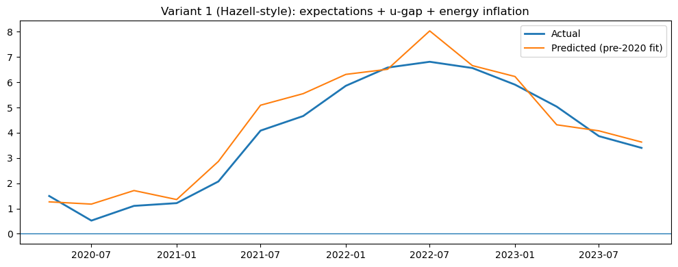

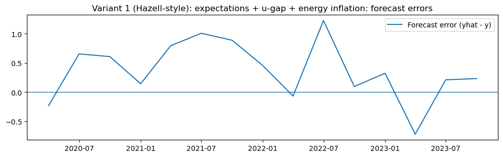

```python
y = "pi_pce_yoy"
slack = "u_gap_nroust"
exp = "exp_mich_1y_mean" if "exp_mich_1y_mean" in df_full.columns else "exp_mich_1y_median"

pc_energy = run_and_plot(
    name="Variant 1 (Hazell-style): expectations + u-gap + energy inflation",
    y=y,
    x=[exp, slack, "pi_pce_energy_yoy"]
)
```

### Phillips curve variant 1: Hazell-style energy control

Hazell’s comment argues that a key reason a simple pre-2020 Phillips curve appears to “fail” post-2020 is the presence of large cost-push/supply shocks, especially energy-price inflation—which are omitted in baseline specifications.
To test this, we augment the baseline expectations-augmented Phillips curve with PCE energy inflation: $$\pi_t = \alpha + \beta\,\pi^e_t + \kappa\,slack_t + \gamma\,\pi^{energy}_t + \varepsilon_t.$$

- If adding energy inflation materially reduces the systematic underprediction during 2021–2022 (lower RMSE and a bias closer to zero), then part of the “Phillips curve forecasting failure” reflects omitted cost-push shocks rather than a breakdown in the slack–inflation mapping.
- If the underprediction remains large even after controlling for energy inflation, then the explanation likely lies in expectations measurement, slack mismeasurement, nonlinearity, or parameter instability.

### Variant 1 result (Hazell-style): adding energy inflation

**Interpretation.**  
This supports the view emphasized in Hazell’s comment: the apparent post-pandemic “failure” of a simple Phillips curve can reflect omitted cost-push shocks (here proxied by energy inflation), rather than a breakdown of the underlying slack–inflation relationship.

### **Bottlenecks/global supply proxy: adding import-price inflation**

```
Variant 2A: expectations + u-gap + import deflator inflation
Spec: pi_pce_yoy ~ exp_mich_1y_mean + u_gap_nroust + import_def_yoy
Train N=204 | Test N=15 | RMSE=0.708 | MAE=0.591 | Bias=0.111
```

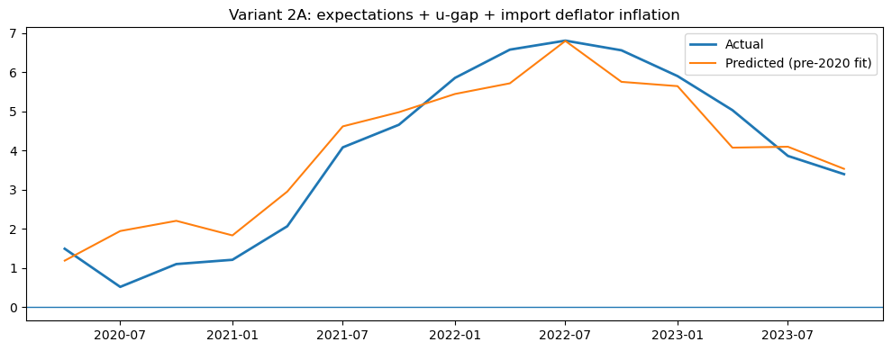

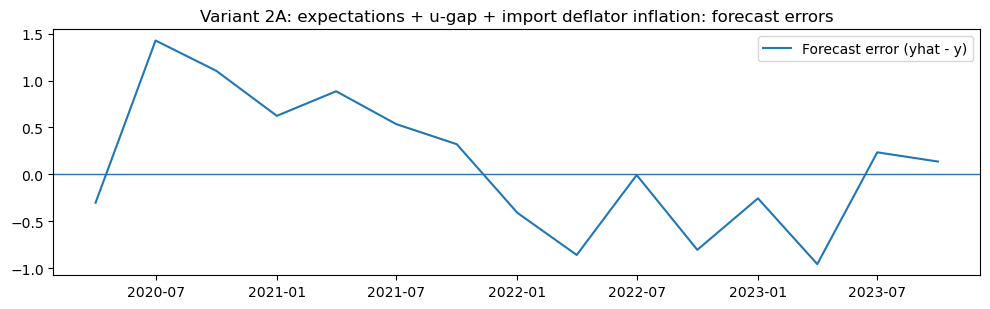

```
Variant 2B: expectations + u-gap + import deflator + oil inflation
Spec: pi_pce_yoy ~ exp_mich_1y_mean + u_gap_nroust + import_def_yoy + oil_yoy
Train N=180 | Test N=15 | RMSE=0.759 | MAE=0.620 | Bias=0.101
```

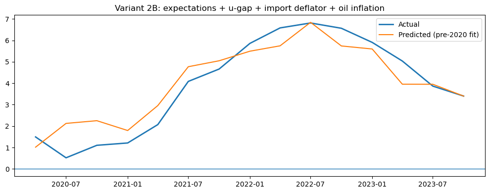

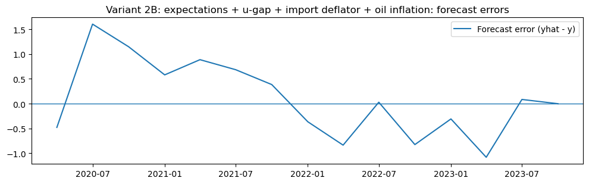

```python
# -----------------------------
# PC Variant 2: Bottlenecks / global supply proxies
# -----------------------------
y = "pi_pce_yoy"
slack = "u_gap_nroust"

# Use your preferred expectations proxy (best from horse race)
exp = "exp_mich_1y_mean" if "exp_mich_1y_mean" in df_full.columns else "exp_mich_1y_median"

# Variant 2A: add import-price inflation
pc_import = run_and_plot(
    name="Variant 2A: expectations + u-gap + import deflator inflation",
    y=y,
    x=[exp, slack, "import_def_yoy"]
)

# Variant 2B (optional): add import prices + oil inflation
pc_import_oil = run_and_plot(
    name="Variant 2B: expectations + u-gap + import deflator + oil inflation",
    y=y,
    x=[exp, slack, "import_def_yoy", "oil_yoy"]
)
```

### Variant 2: bottlenecks / global supply narrative (import prices and oil)

A prominent post-pandemic narrative attributes much of the inflation surge to **global supply disruptions (“bottlenecks”) and input-cost shocks**, rather than domestic slack alone. Papers in this vein emphasize disruptions in global production networks, shipping/logistics constraints, and sharp movements in traded-goods prices and commodities as key drivers of 2021–2022 inflation dynamics (e.g., Bai et al. 2024; di Giovanni et al., and related “bottlenecks” work). This channel is also conceptually aligned with Beaudry, Hou & Portier’s “broad-based supply shock” interpretation: many prices rose together because supply-side forces were widespread.

To operationalize this idea within a Phillips-curve forecasting framework (without attempting a full causal decomposition), we augment the expectations-augmented Phillips curve with **import-price inflation** as an observable proxy for global cost-push pressures, and optionally add **oil inflation** to capture commodity input costs: $$ \pi_t = \alpha + \beta\,\pi^e_t + \kappa\,slack_t + \gamma\,\pi_t^{import} \;(+\; \delta\,\pi_t^{oil}) + \varepsilon_t . $$

**How to read the result.**

- If adding import-price inflation reduces the post-2021 underprediction (lower RMSE and bias closer to zero), this supports the view that omitted global supply/cost shocks contributed materially to the baseline OOS “failure.”
- If the improvement is small relative to Variant 1 (energy), it suggests that the key omitted cost-push component captured in this dataset is primarily energy-related, with import prices adding limited incremental forecasting content.
- If performance worsens or coefficients become unstable, that may reflect multicollinearity among supply proxies (energy/import/oil) or the difficulty of separating distinct supply channels in a short post-pandemic window.

### Variant 2 results (bottlenecks proxy): import prices improve OOS fit

Adding import-price inflation (import deflator y/y) substantially improves post-pandemic out-of-sample performance relative to the baseline Phillips curve. In the 2020Q1–2023Q3 window, RMSE falls to **0.708** and the average forecast bias is small (**+0.11pp**), indicating that a global cost-push proxy captures an important component of the inflation surge that the baseline specification missed.

Including oil inflation in addition to import-price inflation does **not** improve performance (RMSE rises to **0.759**) and reduces the usable training sample, suggesting limited incremental predictive content beyond import prices and/or multicollinearity among supply proxies in this short episode.

**Interpretation.**  
Consistent with “bottlenecks / broad-based supply shock” narratives (e.g., Bai et al.; di Giovanni; and related work cited by Hazell), post-pandemic inflation dynamics appear to be strongly influenced by supply-side cost pressures that are not captured by slack and expectations alone. This supports the view that the baseline OOS “failure” reflects omitted supply shocks rather than a breakdown of the Phillips curve concept per se.

```
Variant 3A: expectations + log(V/U) tightness
Spec: pi_pce_yoy ~ exp_mich_1y_mean + log_vu
Train N=204 | Test N=15 | RMSE=0.636 | MAE=0.566 | Bias=0.238
```

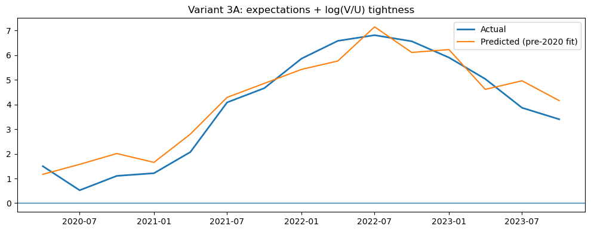

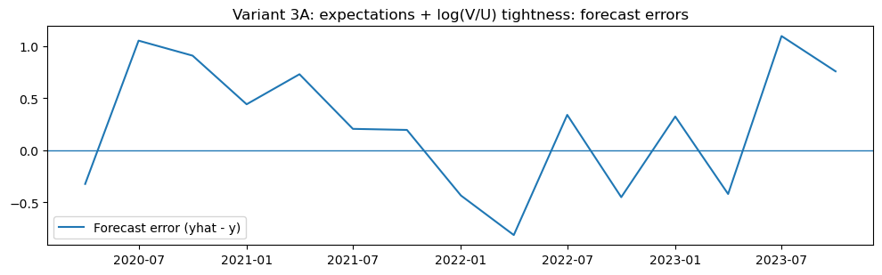

```
Variant 3B: expectations + log(V/U) + energy inflation
Spec: pi_pce_yoy ~ exp_mich_1y_mean + log_vu + pi_pce_energy_yoy
Train N=204 | Test N=15 | RMSE=0.563 | MAE=0.456 | Bias=0.305
```

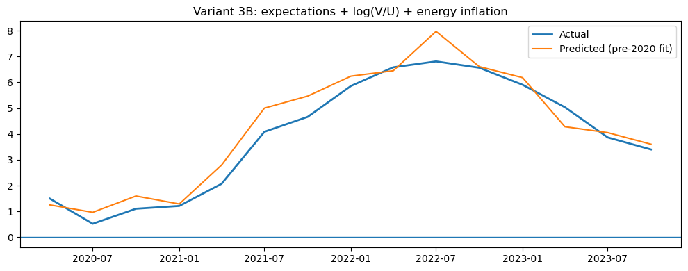

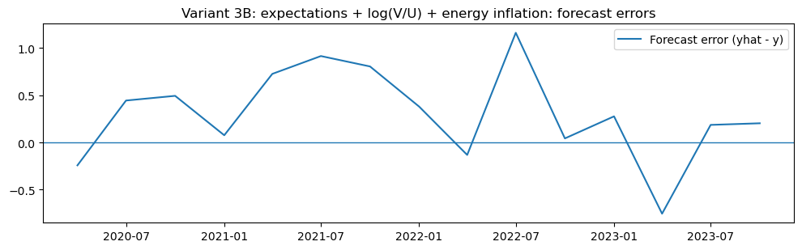

```
Variant 3C: expectations + log(V/U) + import deflator inflation
Spec: pi_pce_yoy ~ exp_mich_1y_mean + log_vu + import_def_yoy
Train N=204 | Test N=15 | RMSE=0.625 | MAE=0.530 | Bias=-0.031
```

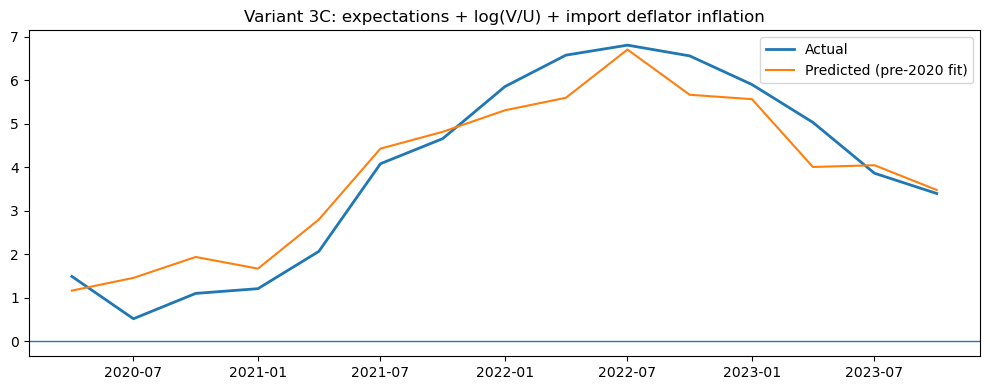

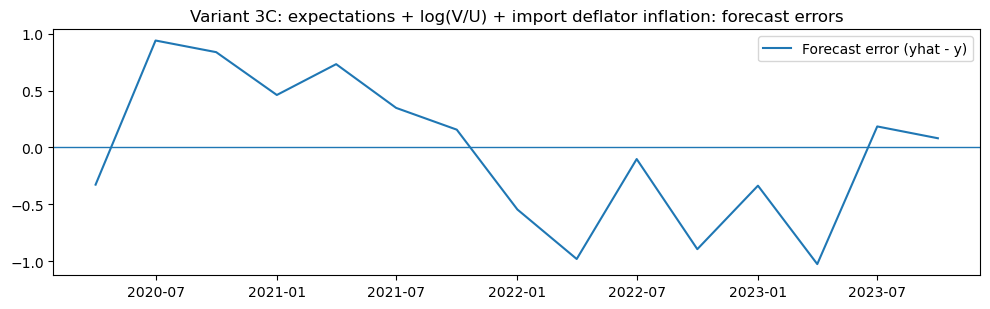

```python
# -----------------------------
# PC Variant 3: Slack = tightness (log V/U)
# -----------------------------
y = "pi_pce_yoy"

# Preferred expectations proxy
exp = "exp_mich_1y_mean" if "exp_mich_1y_mean" in df_full.columns else "exp_mich_1y_median"

# Variant 3A: expectations + log(V/U)
pc_vu = run_and_plot(
    name="Variant 3A: expectations + log(V/U) tightness",
    y=y,
    x=[exp, "log_vu"]
)

# Variant 3B: tightness + Hazell-style energy (often a strong combo)
pc_vu_energy = run_and_plot(
    name="Variant 3B: expectations + log(V/U) + energy inflation",
    y=y,
    x=[exp, "log_vu", "pi_pce_energy_yoy"]
)

# Variant 3C: tightness + import prices (bottlenecks proxy)
pc_vu_import = run_and_plot(
    name="Variant 3C: expectations + log(V/U) + import deflator inflation",
    y=y,
    x=[exp, "log_vu", "import_def_yoy"]
)
```

### Variant 3: labor-market tightness as slack (V/U), with and without supply controls

Post-pandemic labor markets featured unusually high vacancies alongside relatively low unemployment, raising concerns that the unemployment gap may not measure effective slack well when matching frictions and shortages dominate. A related strand of post-pandemic Phillips curve work argues that inflation responds more to **labor-market tightness** (e.g., the vacancy–unemployment ratio) than to unemployment, and that the relationship can steepen when tightness is extreme (Ball et al.; Benigno & Eggertsson; and related work cited in Hazell’s comment).

To operationalize this idea, we replace the unemployment gap with $\log(V/U)$ as the slack proxy in the expectations-augmented Phillips curve: $$\pi_t = \alpha + \beta\,\pi^e_t + \kappa\,\log(V/U)_t + \varepsilon_t.$$ We then consider whether tightness adds predictive power once we also control for cost-push shocks (energy inflation or import-price inflation), since post-pandemic inflation plausibly reflects both labor tightness and supply-side pressures: $$\pi_t = \alpha + \beta\,\pi^e_t + \kappa\,\log(V/U)_t + \gamma Z_t + \varepsilon_t.$$

**How to read the result.**

- If Variant 3A improves OOS fit relative to the unemployment-gap Phillips curve, it supports the view that unemployment was a mismeasured slack proxy post-COVID.
- If Variant 3A alone does not help but Variant 3B/3C does, the interpretation is that tightness matters mainly after controlling for cost-push shocks (i.e., both channels are relevant).
- If tightness performs no better than the unemployment-gap specifications even with supply controls, that weakens the tightness-based Phillips curve narrative in this reduced-form forecasting exercise.

```
Tightness threshold (train 75th pct): -0.233

Variant 3D (Nonlinear slack): exp + log(V/U) + log(V/U)×1{tight}
Spec: pi_pce_yoy ~ exp_mich_1y_mean + log_vu + log_vu_x_tight
Train N=204 | Test N=15 | RMSE=1.004 | MAE=0.859 | Bias=0.827
```

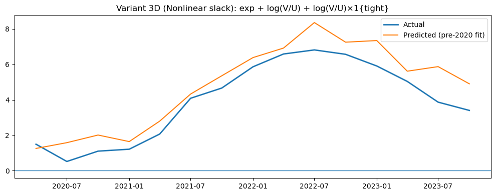

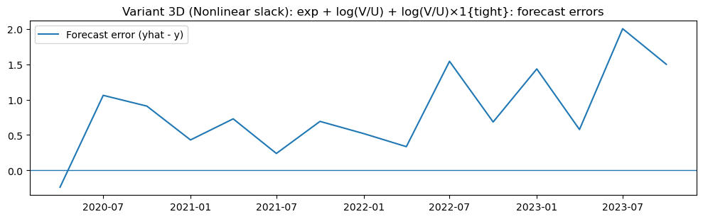

```
Variant 3E (Nonlinear slack + energy): exp + log(V/U) + log(V/U)×1{tight} + energy
Spec: pi_pce_yoy ~ exp_mich_1y_mean + log_vu + log_vu_x_tight + pi_pce_energy_yoy
Train N=204 | Test N=15 | RMSE=1.088 | MAE=0.922 | Bias=0.901
```

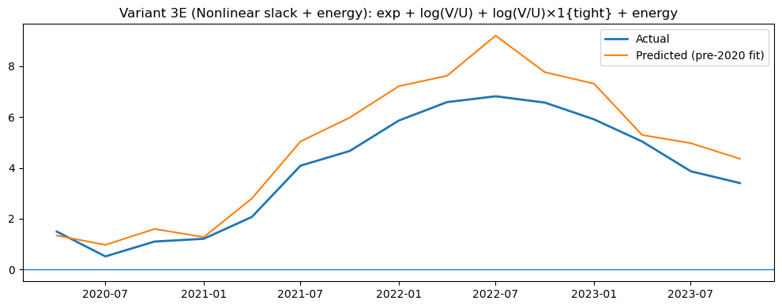

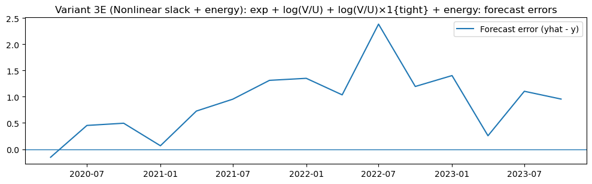

```python
# -----------------------------
# Nonlinearity test: threshold in tightness (log V/U)
# -----------------------------
y = "pi_pce_yoy"
exp = "exp_mich_1y_mean" if "exp_mich_1y_mean" in df_full.columns else "exp_mich_1y_median"

# Choose a tightness threshold beforehand
q = 0.75
vu_thresh = df_train["log_vu"].dropna().quantile(q)
print(f"Tightness threshold (train {int(q*100)}th pct): {vu_thresh:.3f}")

def add_tight_regime(df, vu_thresh):
    d = df.copy()
    d["tight_high"] = (d["log_vu"] >= vu_thresh).astype(float)
    d["log_vu_x_tight"] = d["log_vu"] * d["tight_high"]
    return d

df_train_nl = add_tight_regime(df_train, vu_thresh)
df_test_nl  = add_tight_regime(df_test_common, vu_thresh)

# NL-A: allow slope on log(V/U) to be steeper in high-tightness regime
# pi = a + b*exp + k1*log_vu + k2*(log_vu * 1{tight})
pc_nl_vu = run_and_plot(
    name="Variant 3D (Nonlinear slack): exp + log(V/U) + log(V/U)×1{tight}",
    y=y,
    x=[exp, "log_vu", "log_vu_x_tight"],
    df_train_use=df_train_nl,
    df_test_use=df_test_nl
)

# NL-B: same nonlinearity + energy (Hazell-style cost-push)
pc_nl_vu_energy = run_and_plot(
    name="Variant 3E (Nonlinear slack + energy): exp + log(V/U) + log(V/U)×1{tight} + energy",
    y=y,
    x=[exp, "log_vu", "log_vu_x_tight", "pi_pce_energy_yoy"],
    df_train_use=df_train_nl,
    df_test_use=df_test_nl
)
```